# CSP FINAL_PROJECT

Vishal Balaji

2024-12-13

# This study investigates the relationship between **marijuana use, gender, race**, and the levels of **depression** (categorized as “Several” or “Most”) using the NHANES dataset. The primary goal is to understand how these variables influence depression risk and identify potential interaction effects.

```r
# Set seed for reproducibility
set.seed(123)
df_new <- NHANES[sample(nrow(NHANES), 6000), ]
df_new <-df_new[df_new$Depressed=='Several' | df_new$Depressed=='Most',]

# Select relevant variables for the study
variables <- c('ID', 'Age', 'Gender', 'Race1', 'Marijuana', 'Depressed')
df_new <- df_new[, variables]

# Convert 'Depressed' column into a factor variable with specified levels
df_new$depression_factor <- factor(df_new$Depressed, levels = c("Several", "Most"))

# Data Cleaning
# Remove rows with missing values
df_new <- na.omit(df_new)

# Ensure appropriate data types
df_new$Gender <- factor(df_new$Gender, levels = c("male", "female"))
df_new$Race1 <- factor(df_new$Race1)
df_new$Marijuana <- as.numeric(df_new$Marijuana)

# Descriptive Statistics
# Table summarizing key variables
data_summary <- df_new %>%
  group_by(Gender, Race1) %>%
  summarise(
    Mean_Marijuana = mean(Marijuana, na.rm = TRUE),
    Count_Depressed = table(depression_factor)
  )
print(data_summary)
```

```
## # A tibble: 20 × 4
## # Groups:   Gender, Race1 [10]
##    Gender Race1    Mean_Marijuana Count_Depressed
##    <fct>  <fct>             <dbl> <table[1d]>
##  1 male   Black              1.76  26
##  2 male   Black              1.76  12
##  3 male   Hispanic           1.52  12
##  4 male   Hispanic           1.52  11
##  5 male   Mexican            1.45  35
##  6 male   Mexican            1.45   9
##  7 male   White              1.76 102
##  8 male   White              1.76  37
##  9 male   Other              1.54  20
## 10 male   Other              1.54   4
## 11 female Black              1.58  40
## 12 female Black              1.58  24
## 13 female Hispanic           1.34  25
## 14 female Hispanic           1.34  13
## 15 female Mexican            1.31  38
## 16 female Mexican            1.31  11
## 17 female White              1.75 135
## 18 female White              1.75  54
## 19 female Other              1.5   20
## 20 female Other              1.5   12
```

```r
# Performing Chi-squared test between Gender and Depression
chi_sq_test <- chisq.test(table(df_new$Gender, df_new$depression_factor))
print(chi_sq_test)
```

```
##
##  Pearson's Chi-squared test with Yates' continuity correction
##
## data:  table(df_new$Gender, df_new$depression_factor)
## X-squared = 0.71703, df = 1, p-value = 0.3971
```

```r
# Performing Chi-squared test between Ethnicity and Depression
chi_sq_test_ethnicity <- chisq.test(table(df_new$Race1, df_new$depression_factor))
print(chi_sq_test_ethnicity)
```

```
##
##  Pearson's Chi-squared test
##
## data:  table(df_new$Race1, df_new$depression_factor)
## X-squared = 7.8762, df = 4, p-value = 0.09622
```

```r
# Performing ANOVA for Marijuana Use across Depression Levels
anova_model <- aov(Marijuana ~ depression_factor, data = df_new)
summary(anova_model)
```

```
##                    Df Sum Sq Mean Sq F value Pr(>F)
## depression_factor   1   0.15  0.1502   0.642  0.423
## Residuals         638 149.34  0.2341
```

```r
# Post-hoc test for ANOVA
post_hoc <- TukeyHSD(anova_model)
print(post_hoc)
```

```
##   Tukey multiple comparisons of means
##     95% family-wise confidence level
##
## Fit: aov(formula = Marijuana ~ depression_factor, data = df_new)
##
## $depression_factor
##                     diff        lwr        upr     p adj
## Most-Several -0.03369102 -0.1162712 0.04888913 0.4233458
```

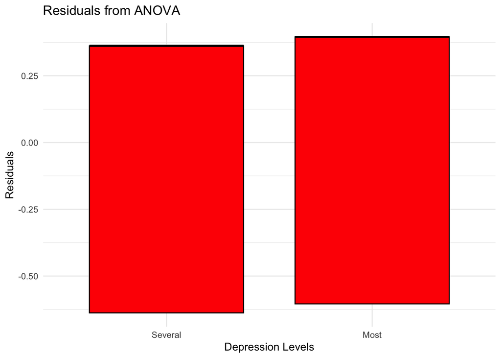

```r
# Residuals to find the direction of association
anova_residuals <- resid(anova_model)
ggplot(df_new, aes(x = depression_factor, y = anova_residuals)) +
  geom_boxplot(fill = "red", color = "black") +
  labs(title = "Residuals from ANOVA", x = "Depression Levels", y = "Residuals") +
  theme_minimal()
```

```r
# Relative Risk/Odds Ratio Estimation
# Creating binary depression outcome (Several vs Most)
df_new$Depression_Binary <- ifelse(df_new$depression_factor == "Most", 1, 0)

# Logistic Regression for Odds Ratio
logistic_model <- glm(Depression_Binary ~ Marijuana + Gender + Race1, data = df_new, family = binomial)
summary(logistic_model)
```

```
##
## Call:
## glm(formula = Depression_Binary ~ Marijuana + Gender + Race1,
##     family = binomial, data = df_new)
##
## Coefficients:
##               Estimate Std. Error z value Pr(>|z|)
## (Intercept)    -0.4398     0.3977  -1.106   0.2687
## Marijuana      -0.1502     0.1899  -0.791   0.4289
## Genderfemale    0.1268     0.1794   0.707   0.4795
## Race1Hispanic   0.1386     0.3375   0.411   0.6814
## Race1Mexican   -0.7180     0.3318  -2.164   0.0305 *
## Race1White     -0.3289     0.2423  -1.357   0.1747
## Race1Other     -0.3230     0.3626  -0.891   0.3730
## ---
## Signif. codes:  0 '***' 0.001 '**' 0.01 '*' 0.05 '.' 0.1 ' ' 1
##
## (Dispersion parameter for binomial family taken to be 1)
##
##     Null deviance: 773.25  on 639  degrees of freedom
## Residual deviance: 764.21  on 633  degrees of freedom
## AIC: 778.21
##
## Number of Fisher Scoring iterations: 4
```

```r
# Calculate Odds Ratios
odds_ratios <- exp(coef(logistic_model))
print(odds_ratios)
```

```
##   (Intercept)     Marijuana  Genderfemale Race1Hispanic  Race1Mexican
##     0.6441330     0.8605293     1.1352090     1.1486297     0.4877225
##    Race1White    Race1Other
##     0.7197079     0.7239387
```

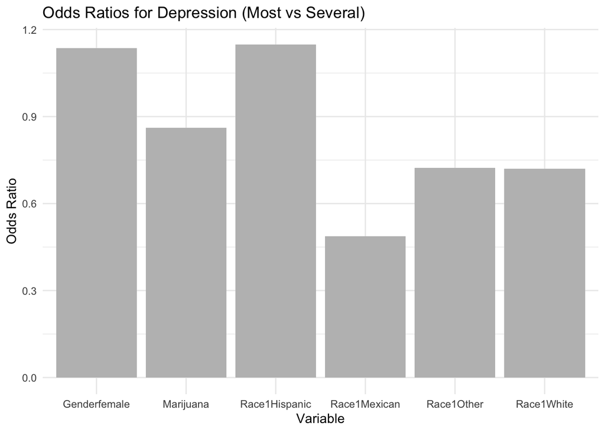

```r
# Visualization of Odds Ratios
library(ggplot2)
odds_ratios_df <- data.frame(
  Variable = names(odds_ratios),
  OddsRatio = odds_ratios
)

ggplot(odds_ratios_df[-1,], aes(x = Variable, y = OddsRatio)) +
  geom_bar(stat = "identity", fill = "grey") +
  labs(title = "Odds Ratios for Depression (Most vs Several)", x = "Variable", y = "Odds Ratio") +
  theme_minimal()
```

```r
# Interaction Effects
interaction_model <- glm(Depression_Binary ~ Marijuana * Gender, data = df_new, family = binomial)
summary(interaction_model)
```

```
##
## Call:
## glm(formula = Depression_Binary ~ Marijuana * Gender, family = binomial,
##     data = df_new)
##
## Coefficients:
##                        Estimate Std. Error z value Pr(>|z|)
## (Intercept)             -1.3071     0.5186  -2.520   0.0117 *
## Marijuana                0.1934     0.2963   0.653   0.5139
## Genderfemale             1.0144     0.6399   1.585   0.1129
## Marijuana:Genderfemale  -0.5242     0.3737  -1.403   0.1607
## ---
## Signif. codes:  0 '***' 0.001 '**' 0.01 '*' 0.05 '.' 0.1 ' ' 1
##
## (Dispersion parameter for binomial family taken to be 1)
##
##     Null deviance: 773.25  on 639  degrees of freedom
## Residual deviance: 769.84  on 636  degrees of freedom
## AIC: 777.84
##
## Number of Fisher Scoring iterations: 4
```

# **FINAL REPORT :**

# **Introduction**

This study investigates the relationship between **marijuana use, gender, race**, and the levels of **depression** (categorized as “Several” or “Most”) using the NHANES dataset. The primary goal is to understand how these variables influence depression risk and identify potential interaction effects.

# **Data Gathering**

The dataset was sampled from **NHANES**, with 6,000 random observations. The study focused on participants who reported feeling depressed at the “Several” or “Most” level. The relevant variables selected for the analysis are:

- **ID**: Unique identifier for each participant
- **Age**
- **Gender**: Categorized as male or female
- **Race1**: Categories include Black, Hispanic, Mexican, White, and Other
- **Marijuana**: Numeric value indicating marijuana use
- **Depressed**: Levels of depression (“Several” or “Most”)

A derived factor, **depression_factor**, was created to categorize depression levels.

# **Methods for Analysis**

### **Data Cleaning**

- Removed rows with missing values using `na.omit()`.
- Converted **Gender** and **Race1** to factors, and **Marijuana** to a numeric type.

### **Descriptive Statistics**

- Grouped data by **Gender** and **Race1** to calculate the **mean marijuana use** and **count of depression levels**.

### **Chi-Square Tests**

- Tested the association between **Gender** and depression levels.
- Tested the association between **Race1** and depression levels.

### **ANOVA**

- Analyzed differences in marijuana use across depression levels.
- Conducted a **post-hoc Tukey HSD test** to determine specific group differences.

### **Logistic Regression**

- Modeled depression (binary outcome) based on **marijuana use, gender, and race**.
- Calculated **odds ratios** to assess the risk factors.
- Tested **interaction effects** between marijuana use and gender.

# **Analysis of Data**

## **Descriptive Statistics**

- Mean marijuana use was summarized for each combination of **Gender** and **Race1**.
- The depression counts by group were also tabulated.

## **Chi-Square Tests**

### **Gender and Depression**

- **p-value = 0.3971** (Not significant)  
  No significant association between gender and depression levels.

### **Race and Depression**

- **p-value = 0.0962** (Not significant at 0.05 level)  
  No significant association between race and depression levels.

## **ANOVA for Marijuana Use**

- **p-value = 0.423** (Not significant)  
  No significant difference in marijuana use between participants reporting “Several” and “Most” depression levels.

### **Post-Hoc Test**

- No significant pairwise differences in marijuana use between the depression groups.

## **Logistic Regression**

### **Model Predictors**

- **Marijuana**: Estimate = -0.1502, p-value = 0.4289 (Not significant)
- **Gender (female)**: Estimate = 0.1268, p-value = 0.4795 (Not significant)
- **Race1 (Mexican)**: Estimate = -0.7180, p-value = 0.0305 (Significant)

### **Odds Ratios**

- **Marijuana**: 0.86 (Not significant)
- **Gender (female)**: 1.14 (Not significant)
- **Race (Mexican)**: 0.49 (Significant) – Lower odds of reporting “Most” depression compared to the baseline group.

## **Interaction Effects**

- **Marijuana × Gender Interaction**:  
  **p-value = 0.1607** (Not significant)  
  The interaction between marijuana use and gender did not significantly affect depression levels.

# **Conclusion**

### **Summary**

The study did not find strong evidence linking marijuana use or gender to higher depression levels. However, race (specifically identifying as Mexican) showed a protective effect against severe depression.

# **Future Scope**

### **Larger Sample Size**

- Increase the dataset size to enhance statistical power and detect subtle effects.

### **Additional Variables**

- Include other mental health factors, socioeconomic status, education levels, and substance use patterns.

### **Longitudinal Analysis**

- Conduct a longitudinal study to observe changes in depression over time and how marijuana use influences these changes.

### **Mental Health Interventions**

- Explore how mental health services or interventions impact depression levels across different demographics.

### **Machine Learning Models**

- Use advanced models to capture non-linear relationships and interactions more effectively.

### **Psychosocial Factors**

- Investigate the impact of social support, stress, and life events on depression risk.

### **Interaction Studies**

- Examine interactions between marijuana use, gender, race, and other lifestyle factors (e.g., physical activity, diet).

This expanded scope can provide a more comprehensive understanding of the factors influencing depression.